# 8. ANOVA Extensions

jsg

Last compiled on 02 November, 2022 15:35

Before doing this, review the **8. 2-way Anova** lecture set slides from https://sites.google.com/view/biostats/lessons/2-way-anovas-and-interactions and the **8_Blocking_and_interactions.R** script in the lecture files folder of the [CUNY-BioStats github repository](https://github.com/jsgosnell/CUNY-BioStats). Make sure you are comfortable with null and alternative hypotheses and appropriate plots for all examples.

Remember you should

- add code chunks by clicking the *Insert Chunk* button on the toolbar or by pressing *Ctrl+Alt+I* to answer the questions!
- **knit** your file to produce a markdown version that you can see!
- save your work often
  - **commit** it via git!
  - **push** updates to github

## Examples

### If interaction is significant

Following the memory example from class, read in and check data

```r
memory <- read.table("http://www.statsci.org/data/general/eysenck.txt", header = T,
                     stringsAsFactors = T)
str(memory)
```

```
## 'data.frame':    100 obs. of  3 variables:
##  $ Age    : Factor w/ 2 levels "Older","Younger": 2 2 2 2 2 2 2 2 2 2 ...
##  $ Process: Factor w/ 5 levels "Adjective","Counting",..: 2 2 2 2 2 2 2 2 2 2 ...
##  $ Words  : num  8 6 4 6 7 6 5 7 9 7 ...
```

Let’s put younger level first

```r
library(plyr)
memory$Age <- relevel(memory$Age, "Younger")
```

and graph

```r
library(Rmisc)
```

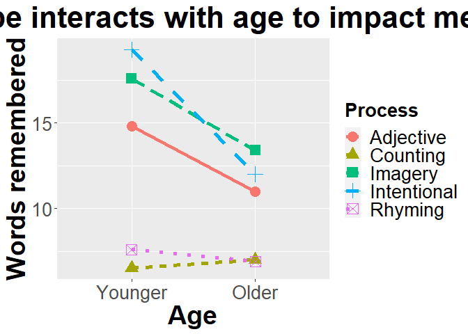

```r
function_output <- summarySE(memory, measurevar="Words", groupvars =
                               c("Age", "Process"), na.rm = T)
library(ggplot2)
ggplot(function_output, aes(x=Age, y=Words,color=Process,
                                   shape = Process)) +
  geom_line(aes(group=Process, linetype = Process), size=2) +
    geom_point(size = 5) +
  ylab("Words remembered")+
  xlab("Age") +
  ggtitle("Process type interacts with age to impact memory")+
  theme(axis.title.x = element_text(face="bold", size=28),
        axis.title.y = element_text(face="bold", size=28),
        axis.text.y  = element_text(size=20),
        axis.text.x  = element_text(size=20),
        legend.text =element_text(size=20),
        legend.title = element_text(size=20, face="bold"),
        plot.title = element_text(hjust = 0.5, face="bold", size=32))
```

There appears to be some interactions. Let’ build a model

```r
memory_interactions <- lm(Words ~ Age * Process, memory)
```

and check assumptions.

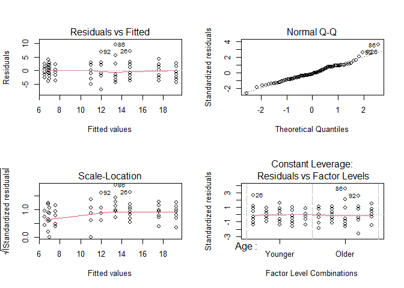

```r
par(mfrow=c(2,2))
plot(memory_interactions)
```

These appear to be met, so look at output

```r
library(car)
Anova(memory_interactions, type = "III")
```

```
## Anova Table (Type III tests)
##
## Response: Words
##             Sum Sq Df  F value    Pr(>F)
## (Intercept) 2190.4  1 272.9281 < 2.2e-16 ***
## Age           72.2  1   8.9963 0.0034984 **
## Process     1353.7  4  42.1690 < 2.2e-16 ***
## Age:Process  190.3  4   5.9279 0.0002793 ***
## Residuals    722.3 90
## ---
## Signif. codes:  0 '***' 0.001 '**' 0.01 '*' 0.05 '.' 0.1 ' ' 1
```

Since interaction is significant, analyze subsets. For example,

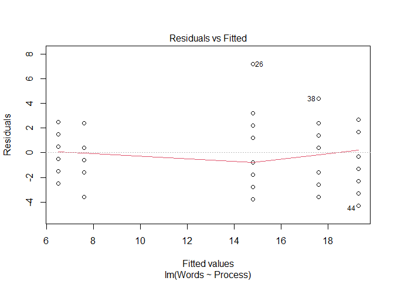

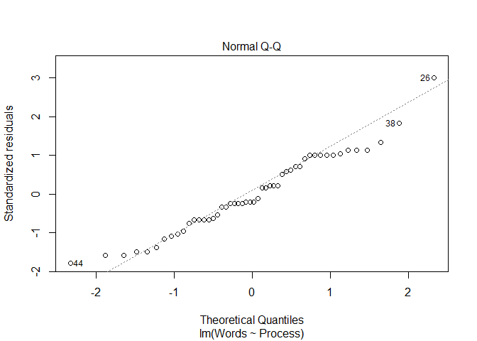

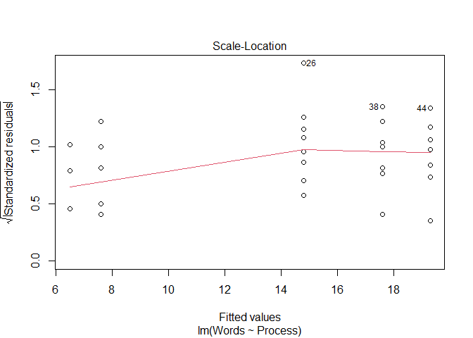

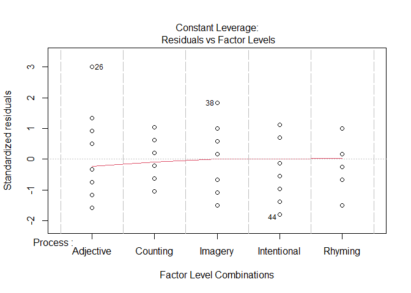

```r
memory_interactions_young <- lm(Words ~ Process, memory[memory$Age == "Younger",])
plot(memory_interactions_young)
```

```r
Anova(memory_interactions_young, type = "III")
```

```
## Anova Table (Type III tests)
##
## Response: Words
##             Sum Sq Df F value    Pr(>F)
## (Intercept) 2190.4  1 343.442 < 2.2e-16 ***
## Process     1353.7  4  53.064 < 2.2e-16 ***
## Residuals    287.0 45
## ---
## Signif. codes:  0 '***' 0.001 '**' 0.01 '*' 0.05 '.' 0.1 ' ' 1
```

There is a significant difference in words recalled based on process, but why? Investigate with post-hoc tests.

```r
library(multcomp)
comp_young <- glht(memory_interactions_young, linfct = mcp(Process = "Tukey"))
summary(comp_young)
```

```
##
##   Simultaneous Tests for General Linear Hypotheses
##
## Multiple Comparisons of Means: Tukey Contrasts
##
##
## Fit: lm(formula = Words ~ Process, data = memory[memory$Age == "Younger",
##     ])
##
## Linear Hypotheses:
##                              Estimate Std. Error t value Pr(>|t|)
## Counting - Adjective == 0      -8.300      1.129  -7.349  < 1e-04 ***
## Imagery - Adjective == 0        2.800      1.129   2.479  0.11360
## Intentional - Adjective == 0    4.500      1.129   3.984  0.00216 **
## Rhyming - Adjective == 0       -7.200      1.129  -6.375  < 1e-04 ***
## Imagery - Counting == 0        11.100      1.129   9.828  < 1e-04 ***
## Intentional - Counting == 0    12.800      1.129  11.333  < 1e-04 ***
## Rhyming - Counting == 0         1.100      1.129   0.974  0.86545
## Intentional - Imagery == 0      1.700      1.129   1.505  0.56454
## Rhyming - Imagery == 0        -10.000      1.129  -8.854  < 1e-04 ***
## Rhyming - Intentional == 0    -11.700      1.129 -10.359  < 1e-04 ***
## ---
## Signif. codes:  0 '***' 0.001 '**' 0.01 '*' 0.05 '.' 0.1 ' ' 1
## (Adjusted p values reported -- single-step method)
```

### Blocking example

Following feather color example from class:

```r
# more than 2? ####
feather <-  read.csv("https://raw.githubusercontent.com/jsgosnell/CUNY-BioStats/master/datasets/wiebe_2002_example.csv
", stringsAsFactors = T)
str(feather)
```

```
## 'data.frame':    32 obs. of  3 variables:
##  $ Bird       : Factor w/ 16 levels "A","B","C","D",..: 1 2 3 4 5 6 7 8 9 10 ...
##  $ Feather    : Factor w/ 2 levels "Odd","Typical": 2 2 2 2 2 2 2 2 2 2 ...
##  $ Color_index: num  -0.255 -0.213 -0.19 -0.185 -0.045 -0.025 -0.015 0.003 0.015 0.02 ...
```

```r
set.seed(25)
special <- data.frame(Bird = LETTERS[1:16], Feather = "Special",
                      Color_index= feather[feather$Feather == "Typical", "Color_index"] +
                        .3 +runif(16,1,1)*.01)
feather <- merge(feather, special, all = T)


Anova(lm(Color_index ~ Feather + Bird, data=feather), type= "III")
```

```
## Anova Table (Type III tests)
##
## Response: Color_index
##              Sum Sq Df  F value    Pr(>F)
## (Intercept) 0.36392  1  59.9538 1.224e-08 ***
## Feather     1.67906  2 138.3093 7.208e-16 ***
## Bird        0.34649 15   3.8055 0.0008969 ***
## Residuals   0.18210 30
## ---
## Signif. codes:  0 '***' 0.001 '**' 0.01 '*' 0.05 '.' 0.1 ' ' 1
```

```r
library(multcomp)
compare <- glht(lm(Color_index ~ Feather + Bird, data=feather), linfct = mcp("Feather" = "Tukey"))
summary(compare)
```

```
##
##   Simultaneous Tests for General Linear Hypotheses
##
## Multiple Comparisons of Means: Tukey Contrasts
##
##
## Fit: lm(formula = Color_index ~ Feather + Bird, data = feather)
##
## Linear Hypotheses:
##                        Estimate Std. Error t value Pr(>|t|)
## Typical - Odd == 0      0.13713    0.02755   4.978   <1e-04 ***
## Special - Odd == 0      0.44712    0.02755  16.232   <1e-04 ***
## Special - Typical == 0  0.31000    0.02755  11.254   <1e-04 ***
## ---
## Signif. codes:  0 '***' 0.001 '**' 0.01 '*' 0.05 '.' 0.1 ' ' 1
## (Adjusted p values reported -- single-step method)
```

```r
#note comparison doesn't work
Anova(lm(Color_index ~ Feather * Bird, data=feather), type= "III")
```

```
## Error in Anova.lm(lm(Color_index ~ Feather * Bird, data = feather), type = "III"): residual df = 0
```

## Practice

### 1

1. A survey was conducted to see if athletes and non-athletes deal with anger in the same way. Data is @

angry <- read.csv(“https://docs.google.com/spreadsheets/d/e/2PACX-1vSaawG37o1ZUEs1B4keIJpZAY2c5tuljf29dWnzqQ0tHNCzfbz85AlWobYzBQ3nPPXJBLP-FWe4BNZB/pub?gid=1784556512&single=true&output=csv”, stringsAsFactors = T)

and more information is at

http://onlinestatbook.com/case_studies/angry_moods.html.

Focus on the following variables:

Sports 1 = athletes, 2 = non-athletes Gender 1 = males, 2 = females Expression (AE) index of general anger expression: (Anger-Out) + (Anger-In) - (Control-Out) - (Control-In) + 48

Is there any evidence that gender or athlete status impact how anger is expressed?

### 2

2. A professor carried out a long-term study to see how various factors impacted pulse rate before and after exercise. Data can be found at http://www.statsci.org/data/oz/ms212.txt With more info at http://www.statsci.org/data/oz/ms212.html. Is there evidence that frequency of exercise (Exercise column) and gender impact change in pulse rate for students who ran (Ran column = 1)?

### 3

3. (Continuing from question 2) I’m curious if the treatment (running vs not) even had an impact, and if so did it depend on gender. How would you test this?